# Práctica 12

# Práctica 12. Análisis de expresión diferencial

### Ejercicio 1

```r
muestras <- read.table('../bioinfo/data/dme_elev_samples.tsv', header = TRUE)
genex <- read.table('../bioinfo/data/salmon.merged.gene_counts.tsv',
                    header = TRUE)
```

1. Usa la función paste() para añadir una columna a muestras que contenga la población y la temperatura unidas por _.

```r
muestras$grupo <- paste(muestras$population, muestras$temp, sep = "_")

head(muestras)
```

```
      sample population temp      grupo
1 SRR1576457      maine  low  maine_low
2 SRR1576458      maine  low  maine_low
3 SRR1576459      maine  low  maine_low
4 SRR1576460      maine high maine_high
5 SRR1576461      maine high maine_high
6 SRR1576462      maine high maine_high
```

2. ¿Cuál es el número total de lecturas por muestra?

```r
colSums(genex[ , -c(1,2)])
```

```
SRR1576457 SRR1576458 SRR1576459 SRR1576460 SRR1576461 SRR1576462 SRR1576463
  28252778   21565448   29471559   27692134   26953900   29368135   29706071
SRR1576464 SRR1576465 SRR1576514 SRR1576515 SRR1576516
  26757043   26596118   30950499   25563787   24401671
```

Este código nos da el total de lecturas para cada muestra.

3. ¿Los recuentos tienen distribuciones parecidas entre muestras?

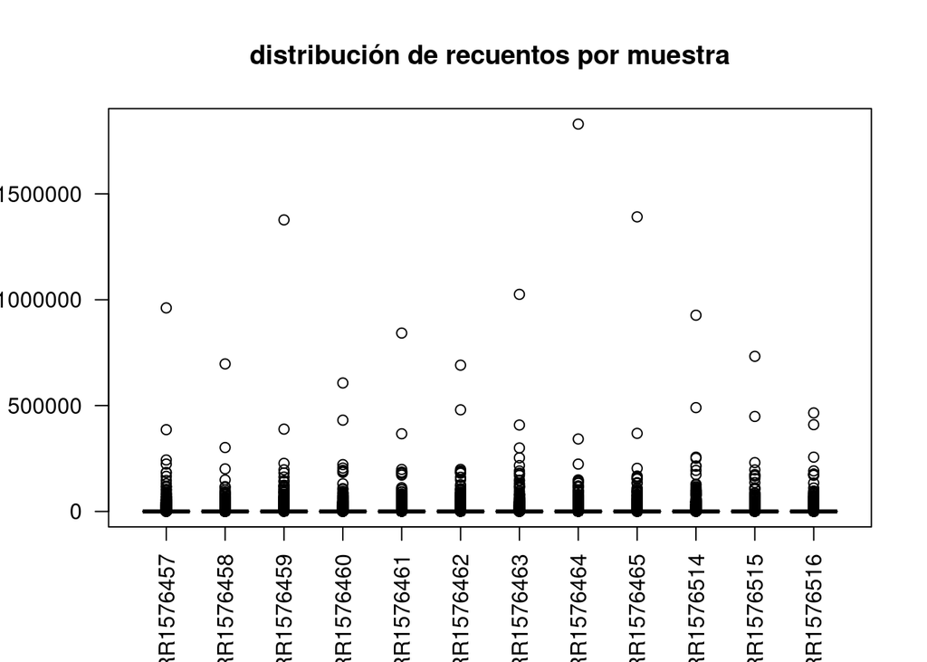

```r
boxplot(genex[ , -c(1, 2)], las = 2, main = "distribución de recuentos por muestra")
```

De manera general sí observamos un número de lecturas similar entre las 12 muestras.

Otra forma:

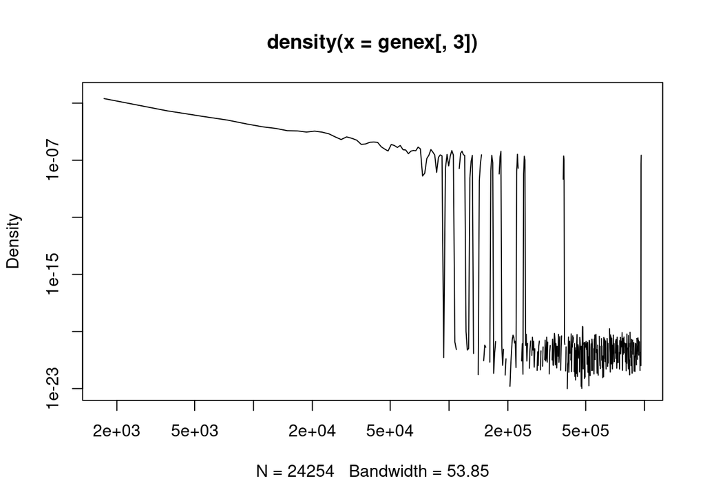

```r
plot(density(genex[ , 3]), log='xy')
```

4. ¿Cuántos genes no se expresan en absoluto en ninguna de las muestras?

```r
# 1. Separamos solo las columnas numéricas (de la 3 en adelante)
conteos <- genex[, 3:ncol(genex)]

# 2. Identificamos qué filas suman 0 en todas las muestras
genes_no_expresados_idx <- rowSums(conteos) == 0

# 3. Extraemos la información de esos genes
genes_nulos <- genex[genes_no_expresados_idx, c("gene_id", "gene_name")]

# Ver el total y los primeros resultados
nrow(genes_nulos)
```

```
[1] 4722
```

```r
head(genes_nulos)
```

```
        gene_id      gene_name
69  FBgn0000216            Brd
93  FBgn0000280       Cec-Psi1
94  FBgn0000281           Cec2
662 FBgn0003865            tsg
677 FBgn0003920   snRNA:U2:14B
679 FBgn0003923 snRNA:U2:38ABb
```

## Crear el objeto de clase DESeqDataSet

```r
# para que las filas de la tabla muestras estén en el mismo orden que las columnas en genex:
suppressMessages(library('DESeq2'))
all(names(genex)[3:14] == muestras$sample) #si ejecutamos esto dará TRUE, es una comprobación. Lo que comprueba es que los nombres de las columnas 3 a la 14 de genex tienen los mismos nombres que la columna sample de muestras.
```

```
[1] TRUE
```

```r
# Pasamos la columna "sample" a nombres de fila:
row.names(muestras) <- muestras$sample #sirve para facilitar el trabajo después, nos quedamos solo con los factores.

# Eliminamos la columna "sample", pues esta información está en los nombres de las filas:
muestras$sample <- NULL

# Y convertimos "population" y "temp" en factores (variables categoricas que solo admiten unos valores concretos posibles):
muestras$population <- factor(muestras$population,
                              levels = c('maine', 'panama'))
muestras$temp       <- factor(muestras$temp,
                              levels = c('low', 'high'))
muestras
```

```
           population temp       grupo
SRR1576457      maine  low   maine_low
SRR1576458      maine  low   maine_low
SRR1576459      maine  low   maine_low
SRR1576460      maine high  maine_high
SRR1576461      maine high  maine_high
SRR1576462      maine high  maine_high
SRR1576463     panama  low  panama_low
SRR1576464     panama  low  panama_low
SRR1576465     panama  low  panama_low
SRR1576514     panama high panama_high
SRR1576515     panama high panama_high
SRR1576516     panama high panama_high
```

```r
# Los datos de recuento deben ser números enteros y en forma de matriz. El programa saca medias de lectura cuando no sabe si una lectura puede ser de un gen o de otro, por esto es que debemos utilizar round para que se redondeen a números enteros.
row.names(genex) <- genex$gene_name
genex$gene_name <- NULL
genex$gene_id   <- NULL # nos deshacemos de todo el contenido no numérico en la tabla
genex <- round(as.matrix(genex))

#Creamos este objeto a partir de la matriz:
dds1 <- DESeqDataSetFromMatrix(
   countData = genex, # recuento de lecturas que mapean cada gen
   colData = muestras, # datos de las culumnas, que son las muestras. la cosa es que la info de cada columna de muestras debe coincidir con las de las filas de genex. Esto no lo comprueba, por lo que es importante que lo hayamos hecho nosotros antes.
   design = ~ population + temp # son las variables explicativas para la varible respuesta (la expresión de los genes)
)
dds1
```

```
class: DESeqDataSet
dim: 24254 12
metadata(1): version
assays(1): counts
rownames(24254): 7SLRNA:CR32864 a ... RR51477 Bari1{}RR51478
rowData names(0):
colnames(12): SRR1576457 SRR1576458 ... SRR1576515 SRR1576516
colData names(3): population temp grupo
```

Una fracción importante de genes no se están expresando en ningúna muestra. Para eliminarlos de los datos que vamos a seguir utilizando el resto de la práctica:

```r
keep <- rowSums(counts(dds1)) > 0 # usamos counts para acceder a la matriz que en este momento es idéntica a genex. Le decimos que sume las filas y diga en qué filas la suma es mayor a 0 (el resultado es una serie de TRUE,TRUE, FALSE..., y será FALSE en aquellas donde no se expresa el gen en ninguna muestra).
# Este vector después sirve para seleccionar las filas que nos quedamos:
dds1 <- dds1[keep, ]
```

```r
dds1 <- DESeq(dds1)
res <- results(dds1)
res
```

```
log2 fold change (MLE): temp high vs low
Wald test p-value: temp high vs low
DataFrame with 19508 rows and 6 columns
                baseMean log2FoldChange     lfcSE       stat      pvalue
               <numeric>      <numeric> <numeric>  <numeric>   <numeric>
7SLRNA:CR32864   346.333      0.5918974 1.3301901   0.444972 0.656339979
a                555.596     -0.2730041 0.0718487  -3.799708 0.000144866
abd-A            531.996     -0.0286785 0.0789218  -0.363379 0.716321800
Abd-B            634.760     -0.1083918 0.0771241  -1.405420 0.159896347
Abl             1654.842     -0.1328055 0.0746580  -1.778851 0.075264235
...                  ...            ...       ...        ...         ...
RR51007          4.90906      3.8596869  2.972471  1.2984773 1.94123e-01
RR51048         16.60710     -0.8973071  0.341603 -2.6267530 8.62039e-03
RR51093         36.93279      0.0660523  1.685323  0.0391927 9.68737e-01
RR51475        159.62678     -2.6058194  1.875172 -1.3896429 1.64637e-01
RR51477         70.83394      1.6927986  0.192437  8.7966372 1.40977e-18
                      padj
                 <numeric>
7SLRNA:CR32864  0.81170166
a               0.00154574
abd-A           0.85146309
Abd-B           0.33849233
Abl             0.20046251
...                    ...
RR51007        3.82417e-01
RR51048        4.01746e-02
RR51093        9.84464e-01
RR51475        3.44815e-01
RR51477        2.06431e-16
```

```r
# la función results() produce la tabla de resultados para el contraste entre el nivel último y el de referencia del último factor en la tabla que describe las muestras.
#En este caso, el factor es temp, el nivel de referencia es low y el otro nivel es high. Por tanto, los valores de log2FoldChange representan el logaritmo en base 2 de la relación entre niveles de expresión en muestras high respecto de muestras low.
```

Vemos el resultado en una tabla, donde las columnas son basemean, log2foldchange, LFCSE, stat, pval y padj.

-baseMean: nivel de expresión base -log2FoldChange: logaritmo base 2 de la expresión en una concidión respecto a la otra (log2 = expresión en condición x / expresión en referencia). Es importante saber cuál es el valor de referencia, que en este caso era “low”: si es positivo, el gen se expresa más en temperatura alta respecto a la baja, y lo contrario para valores negativos. - lfcSE: error estándar - stat: estadístico - pval: valor p - padj: valor p ajustado porque estamos analizando muchos genes.

### Ejercicio 3

1. Mira la ayuda de results() y genera también la tabla de resultados para el contraste entre las dos regiones de procedencia de las moscas.

Para comparar resultados de la tabla results, utilizamos contrast. Si no le decimos el contraste que queremos hacer no podremos analizar bien los datos. Así, comparamos la expresión diferencial entre panama respecto a maine:

```r
res_poblacion <- results(dds1, contrast = c("population", "panama", "maine"))

head(res_poblacion)
```

```
log2 fold change (MLE): population panama vs maine
Wald test p-value: population panama vs maine
DataFrame with 6 rows and 6 columns
                baseMean log2FoldChange     lfcSE      stat    pvalue      padj
               <numeric>      <numeric> <numeric> <numeric> <numeric> <numeric>
7SLRNA:CR32864   346.333     -0.2116106 1.3301901 -0.159083 0.8736035  0.966480
a                555.596     -0.1114459 0.0718333 -1.551451 0.1207937  0.449953
abd-A            531.996      0.0460822 0.0789226  0.583890 0.5592940  0.838008
Abd-B            634.760     -0.0424386 0.0771227 -0.550274 0.5821316  0.850234
Abl             1654.842     -0.1477705 0.0746581 -1.979298 0.0477825  0.288737
abo              239.891      0.0195463 0.0846639  0.230869 0.8174168  0.947315
```

2. Usa summary() sobre los resultados para ver el número de genes diferencialmente expresados entre cada par de condiciones.

```r
summary(res)
```

```
out of 19508 with nonzero total read count
adjusted p-value < 0.1
LFC > 0 (up)       : 2418, 12%
LFC < 0 (down)     : 2336, 12%
outliers [1]       : 90, 0.46%
low counts [2]     : 3018, 15%
(mean count < 2)
[1] see 'cooksCutoff' argument of ?results
[2] see 'independentFiltering' argument of ?results
```

```r
summary(res_poblacion)
```

```
out of 19508 with nonzero total read count
adjusted p-value < 0.1
LFC > 0 (up)       : 623, 3.2%
LFC < 0 (down)     : 634, 3.2%
outliers [1]       : 90, 0.46%
low counts [2]     : 3018, 15%
(mean count < 2)
[1] see 'cooksCutoff' argument of ?results
[2] see 'independentFiltering' argument of ?results
```

LFC > 0 es que está up-regulated. Cuando es < 0 será down-regulated. Vemos comparando ambos summaries que la variable que más afecta a la expresión génica es la temperatura, pues hay 2418 genes sobreexpresados y 2336 infraexpresados, frente a la menor cantidad de los encontrados en la comparación por región/población.

3. ¿Cuál es la tasa de falsos positivos (FDR)?

La tasa FDR, según la ayuda de DESeq, es igual al umbral del valor de p-valor ajustado, que en summary podemos ver que es 0.1.